[figure not shown]

CURSO SOBRE BIOHERRAMIENTAS EN BIOESTADISTICA Y BIOINFORMATICA  
(1ªEdición)

Barcelona, 16, 17 y 18 de Mayo 2017

Cómo crear aplicaciones con Shiny

Parte II: Diseño del formulario

Elementos de entrada

| Tipo | Función | Argumentos | Ejemplo |
| --- | --- | --- | --- |
| Entrada numérica | `numericInput` | `inputId`, `label`, `value`, `min`, `max`, `step` |  |
| Entrada de texto | `textInput` | `inputId`, `label`, `value`, `width` |  |
| Lista de opciones | `radioButtons` | `inputId`, `label`, `choices`, `selected`, `inline`, `width` |  |
| Lista desplegable | `selectInput` | `inputId`, `label`, `choices`, `selected`, `multiple`, `selectize`, `width`, `size` |  |
| [Lista desplegable](https://github.com/selectize/selectize.js) | `selectizeInput` | … + `options` |  |
| Numérico (mínimo, máximo) | `sliderInput` | `inputId`, `label`, `min`, `max`, `value`, `step`, `animate` |  |
| Verdadero/Falso | `checkboxInput` | `inputId`, `label`, `value`, `width` |  |
| Botón | `actionButton` | `inputId`, `label`, `icon`, `width` |  |

### Listas desplegables

- Se usan las funciones **`selectInput`, `selectizeInput`**.
- Para poder seleccionar más de un ítem **`multiple=TRUE`**.
- Cuando se seleccionar más de un ítem, se puede visualizar la lista en dos formatos distintos:
1. **Formato simple**: una opción debajo de la otra. Puede ser interesante hacer que la ventana sea más o menos larga mediante el argumento `size`.
2. **Formato “selecize”**. Permite buscar las opciones con “texto-sensible”, y añadir más opciones mediante el argumento `options` usando la función `selectizeInput`. Para más información visita la siguiente [web](https://github.com/selectize/selectize.js)

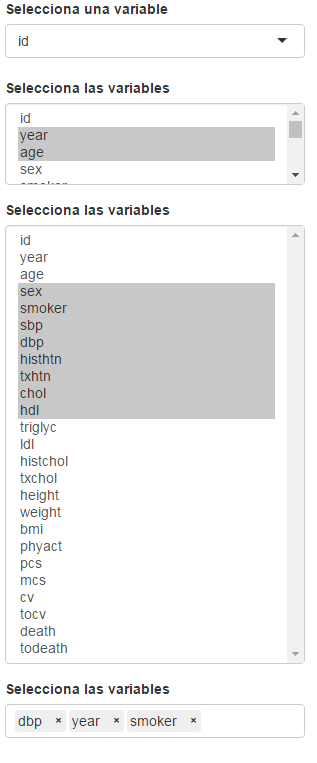

```r
library(compareGroups)
data(regicor)

ui <- fluidPage(

  selectInput("lista1", "Una opción", names(regicor)),

  selectInput("lista2", "Varios. Formato simple", names(regicor),
              multiple=TRUE, selectize=FALSE),

  selectInput("lista3", "Formato simple", names(regicor),
              multiple=TRUE, size=ncol(regicor), selectize=FALSE),

  selectizeInput("lista4", "Formato selectize", names(regicor),
                 multiple=TRUE,
                 options=list(plugins=list('remove_button', 'drag_drop')))

)

server <- function(input, output){}

shinyApp(ui, server)
```

Elementos de salida

Aspecto

Función

Argumentos

Ejemplo

Texto como en la consola de R

`verbatimTextOutput`

`outputId`

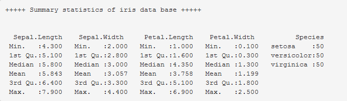

Texto interpretado como HTML

`htmlOutput`

`outputId`, `inline`

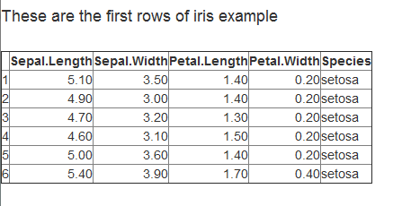

Tabla “simple”

`tableOutput`

`outputId`

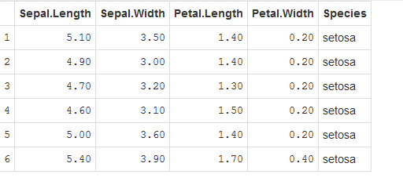

Tabla “compleja”

[`dataTableOutput`](http://rstudio.github.io/DT/)

`outputId`

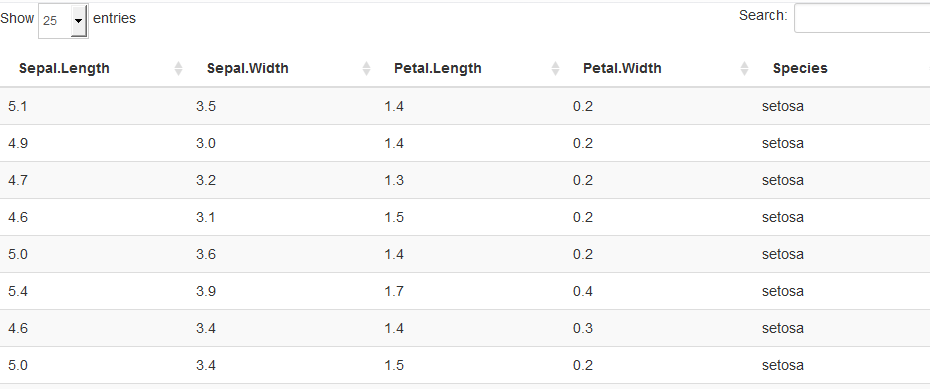

Gráfico

`plotOutput imageOutput`

`outputId`, `width`, `height`, `click`,…

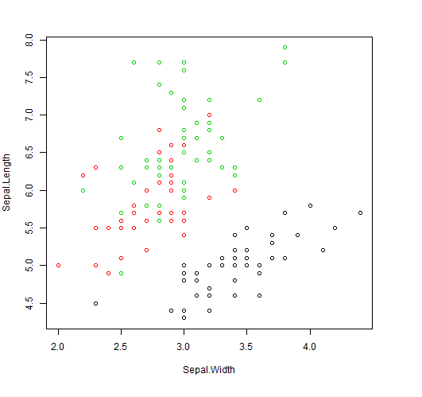

### Texto interpretado en R

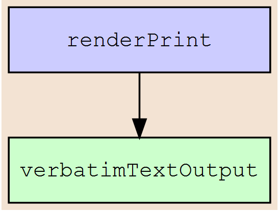

```r
ui <- fluidPage(

  verbatimTextOutput("result")

)

server <- function(input, output) {

  output$result<-renderPrint({
    summary(iris)
  })

}

shinyApp(ui = ui, server = server)
```

### Texto interpretado en HTML

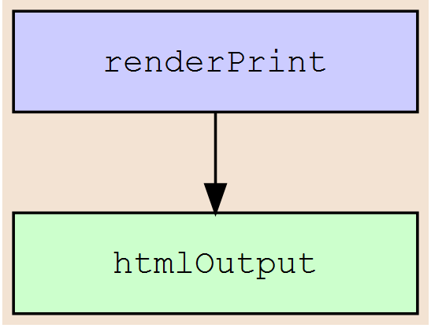

```r
library(xtable)

ui <- fluidPage(

  htmlOutput("result")

)

server <- function(input, output) {

  output$result<-renderPrint({
    print(xtable(head(iris)), type = "html")
  })

}

shinyApp(ui = ui, server = server)
```

**Ejercicio:** substituye `htmlOutput` por `verbatimTextOutput`

### Tabla Simple

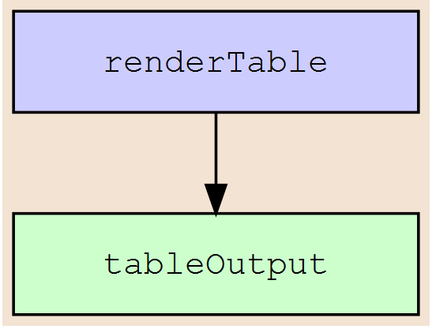

```r
ui <- fluidPage(

  tableOutput("result")

)

server <- function(input, output) {

  output$result<-renderTable({
    head(iris)
  })

}

shinyApp(ui = ui, server = server)
```

### Tabla Compleja

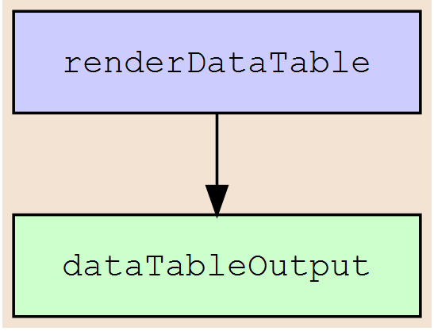

```r
ui <- fluidPage(

  dataTableOutput("result")

)

server <- function(input, output) {

  output$result<-renderDataTable({
    iris
  })

}

shinyApp(ui = ui, server = server)
```

### Gráficos

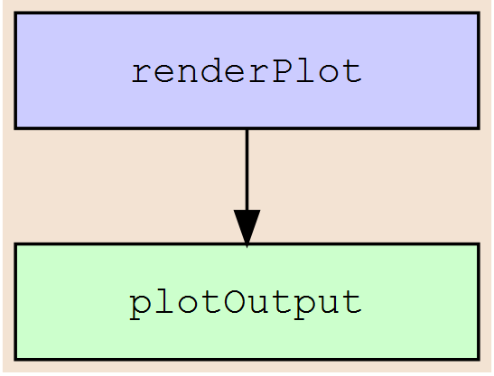

```r
ui <- fluidPage(
  plotOutput("result")
)

server <- function(input, output) {

  output$result<-renderPlot({
    plot(Sepal.Length ~ Sepal.Width,
         col = Species, data = iris)
  }, width = 500, height = 500)

}

shinyApp(ui = ui, server = server)
```

¿Cómo quedaría la figura si no se especifica la anchira ni la altura?

Disposición de los elementos  
*Layout*

### Paneles izquierdo y derecho

```r
fluidPage(

  sidebarLayout(

    sidebarPanel(...),

    mainPanel(...)

  )

)
```

- Es la opción más común
- Equivalentemente, también se puede usar la función `bootstrapPage` en lugar de `fluidPage`.

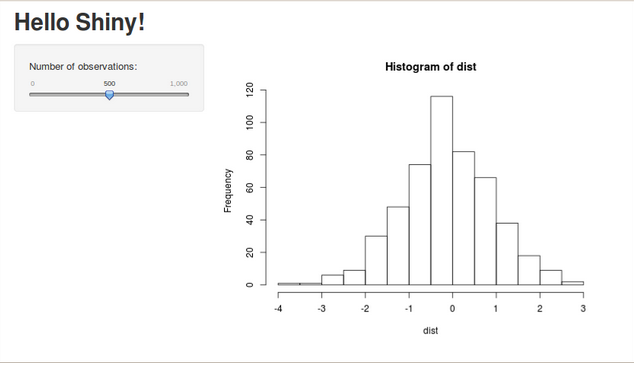

### Especificando filas y columnas

```r
fluidPage(

  fluidRow(
    column(4, ...),
    column(8, ...)
  ),

  fluidRow(
    column(6, ...),
    ...
  ),
  ...
)
```

- Es la opción más flexible
- Se puede especificar la anchura de las columnas
- **No** se puede especificar la altura de las filas
- La suma de las columnas ha de ser 12.
- Se pueden poner tantas columnas como se quiera.
- Cada fila se especifica con **`fluidRow`**.

**Ejercicio:** Completa el código para disponer los elementos como en este ejemplo

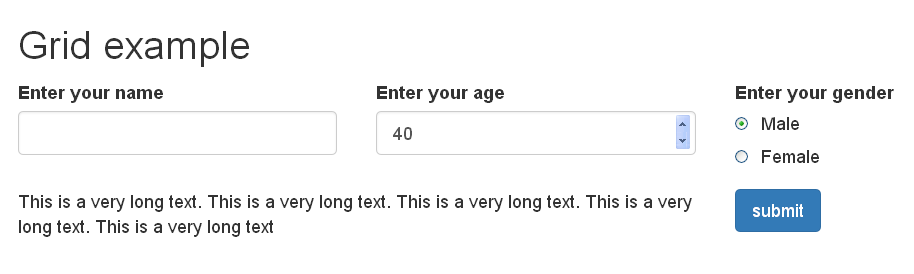

```r
ui <- shinyUI(fluidPage(

  titlePanel("Grid example"),
  ...
  ...

  submitButton("submit","")

))

server <- function(input, output) {}

shinyApp(ui = ui, server = server)
```

### Menú general

```r
navbarPage(

  tabPanel(...),

  tabPanel(...),

)
```

- No es tan usado como los anteriores.
- El funcionamiento es el mismo que para las pestañas que se explicará a continuación.

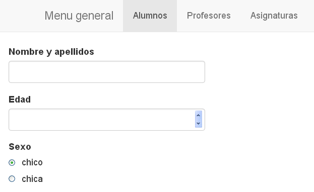

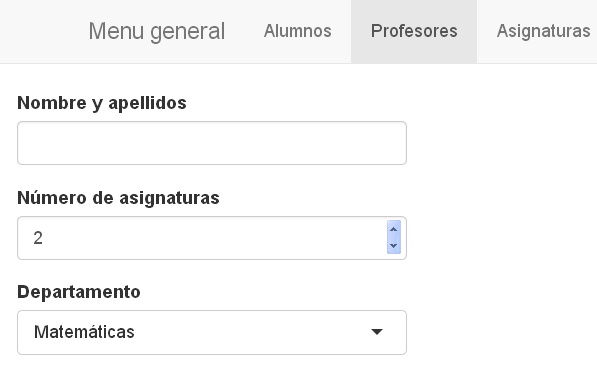

### Pestañas

```r
ui <- fluidPage(

  tabsetPanel(id = "menu",

    tabPanel("Tabla",
    ...
    ),

    tabPanel("Resumen",
    ...
    )

  )

)
```

- Disposición de los elementos uno **detrás** de otro.
- Para crear un conjunto de pestañas se usa la función **`tabsetPanel`**.
- Para la creación de cada pestaña individualmente se usa la función **`tabPanel`**.

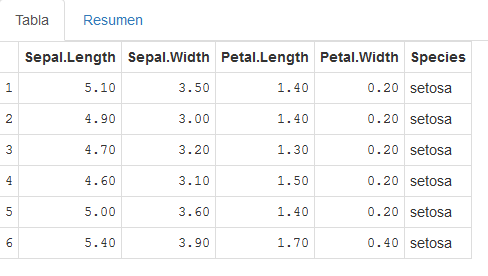

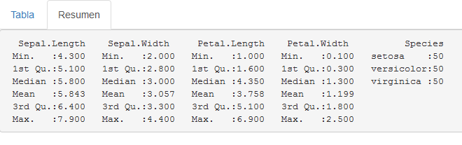

### Desplegables: Unión de varias pestañas en una

```r
ui <- fluidPage(

  tabsetPanel(id="menu", type="pills",

    tabPanel("Pestaña1",
      ...
    ),

    navbarMenu("Desplegable",
      tabPanel("opción1",
        ...
      ),
      tabPanel("opción2",
        ...
      )
    )

  )
)
```

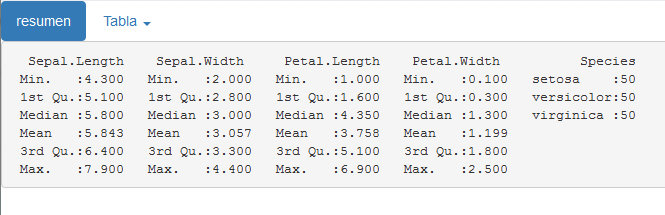

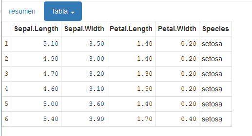

Paneles condicionales

### Paneles condicionales

- Se usan cuando algunos elementos tienen que aparecer o no en función del valor de un input.
- Función **`conditionalPanel`**.
  - Primer argumento: carácter. Condición lógica escrita en **formato “javascript”**.
  - Segundo argumento: elementos del formulario que aparecen si la condición se cumple.

```r
conditionalPanel(

  condition = "input.tipo==1",
  ...

)
```

### Ejemplo 1

```r
ui <- fluidPage(
  radioButtons("tipo",
      "¿Qué quieres mostrar?",
      c("Tabla"=1, "Resumen"=2)),
  conditionalPanel(
    condition = "input.tipo==1",
    tableOutput("result1")
  ),
  conditionalPanel(
    condition = "input.tipo==2",
    verbatimTextOutput("result2")
  )
)

server <- function(input, output) {
  output$result1 <- renderTable(
    head(iris)
  )
  output$result2 <- renderPrint(
    summary(iris)
  )
}

shinyApp(ui = ui, server = server)
```

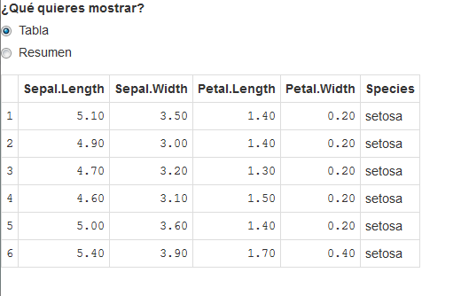

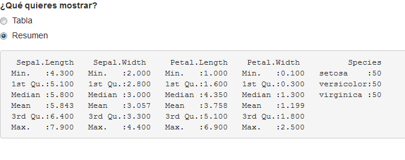

**Ejercicio:** Fíjate que esta opción podría ser una alternativa a `tabsetPanel`. ¿Cómo lo harías?

### Ejemplo 2

```r
ui <- fluidPage(

  checkboxInput("ayuda", "Ayuda"),

  conditionalPanel(
    condition = "input.ayuda",
    helpText("Esto es una
      explicación sobre como
      funciona el aplicativo.")
  )

)

server <- function(input, output) {}

shinyApp(ui = ui, server = server)
```

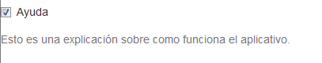

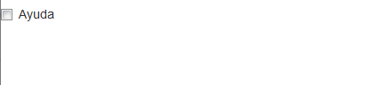

El texto aparece o desaparece.

### Ejemplo 3

```r
library(shiny)

ui <- fluidPage(

  actionButton("toggle", "Toggle"),

  conditionalPanel(
    condition = "input.toggle%2==0",
    helpText("Esto es una explicación
    sobre como funciona el aplicativo.")
  )

)

server <- function(input, output) {}

shinyApp(ui = ui, server = server)
```

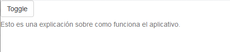

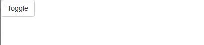

### Ejemplo 4

```r
ui <- fluidPage(

  selectInput("format", "Formato",
    c("SPSS"=1, "EXCEL"=2, "TXT"=3, "R"=4)),

  conditionalPanel(
    condition = "input.format==3",
    wellPanel(
      radioButtons("sep", "Separador",
        c(",", ";", "tab"), inline = TRUE),
      radioButtons("dec", "Decimal",
        c(".", ","), inline = TRUE),
      checkboxInput("header", "Cabecera")
    )
  )

)

server <- function(input, output) {}

shinyApp(ui = ui, server = server)
```

Fíjate en la función `wellPanel` para crear un *frame* alrededor de los elementos, y el argumento `inline` de la función `radioButtons` para disponer las opciones (botones) en horizontal.

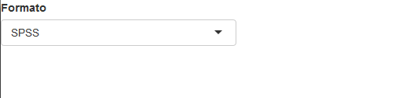

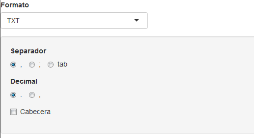

### Ejemplo 5

```r
ui <- fluidPage(
  sidebarLayout(
    sidebarPanel(
      conditionalPanel(
        condition = "input.menu=='panel 1'",
        "Ahora está activo el panel 1"
      ),
      conditionalPanel(
        condition = "input.menu=='panel 2'",
        "Ahora está activo el panel 2"
      )

    ),
    mainPanel(
      tabsetPanel(id = "menu",
        tabPanel("panel 1",
          "Texto en el panel 1"
        ),
        tabPanel("panel 2",
          "Texto en el panel 2"
        )
      )
    )
  )
)

server <- function(input, output) {}

shinyApp(ui = ui, server = server)
```

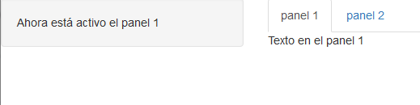

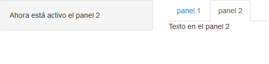

El resultado varía según está activo una pestaña u otra.

Ejercicio

Completa el código de la parte UI para colocar las elementos y pestañas del siguiente formulario.

A la **izquierda del formulario** debe aparecer un panel donde:

- Se escoja una distribución entre
  - exponencial
  - normal
  - binomial
- Según la distribución aparezcan los inputs de los parámetros apropiados para que el usuario introduzca sus valores

A la **derecha del formulario** aparezcan dos pesañas:

- La primera debe contener un histograma de los datos generados según la distribución (1000 datos).
- La segunda pestaña debe contener un `summary` de los datos generados.

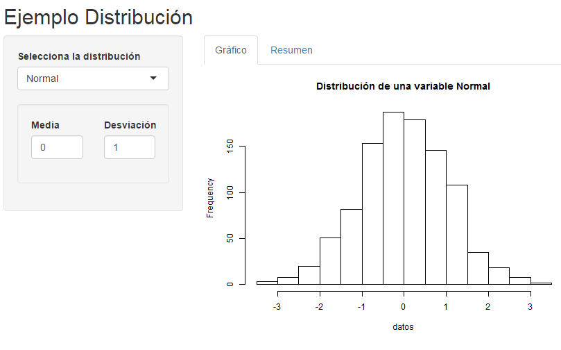

```r
ui <- fluidPage(

   titlePanel("Ejemplo Distribución"),

   sidebarLayout(
      sidebarPanel(
      ## rellenar
      ),

      mainPanel(
      ## rellenar
      )
   )
)
```

```r
server <- function(input, output) {

  output$resumen <- renderPrint({
    if (input$distr=="Normal")
      datos <- rnorm(1000, input$media, input$sd)
    if (input$distr=="Exponencial")
      datos <- rexp(1000, input$lambda)
    if (input$distr=="Binomial")
      datos <- rbinom(1000, input$n, input$p)
    summary(datos)
  })

  output$grafico <- renderPlot({
    if (input$distr=="Normal")
      datos <- rnorm(1000, input$media, input$sd)
    if (input$distr=="Exponencial")
      datos <- rexp(1000, input$lambda)
    if (input$distr=="Binomial")
      datos <- rbinom(1000, input$n, input$p)
    if (input$distr=="Binomial"){
      datosfact <- factor(datos, levels=0:input$n)
      barplot(table(datosfact))
    } else {
      hist(datos, main="")
    }
    title(paste("Distribución ", input$distr))
  })

}
```